# R Recitation - 17 December

Burcu

- foundations + one-way between-subject ANOVA + one-way repeated-measures ANOVA + contrasts + post-hoc corrections.

# 1 1 — Foundations of ANOVA

## 1.1 1. Quick data inspection checklist

- Students often skip checking factor types and end up with numeric IVs.
- In ANOVA, predictors should be **factors**, outcome should be **numeric**.

```r
# A minimal "inspection" template
inspect_data <- function(df) {
  cat("---- STRUCTURE ----\n")
  print(str(df))
  cat("\n---- SUMMARY ----\n")
  print(summary(df))
  cat("\n---- MISSING VALUES ----\n")
  print(colSums(is.na(df)))
}

# Example on a built-in dataset:
inspect_data(mtcars)
```

```
## ---- STRUCTURE ----
## 'data.frame':    32 obs. of  11 variables:
##  $ mpg : num  21 21 22.8 21.4 18.7 18.1 14.3 24.4 22.8 19.2 ...
##  $ cyl : num  6 6 4 6 8 6 8 4 4 6 ...
##  $ disp: num  160 160 108 258 360 ...
##  $ hp  : num  110 110 93 110 175 105 245 62 95 123 ...
##  $ drat: num  3.9 3.9 3.85 3.08 3.15 2.76 3.21 3.69 3.92 3.92 ...
##  $ wt  : num  2.62 2.88 2.32 3.21 3.44 ...
##  $ qsec: num  16.5 17 18.6 19.4 17 ...
##  $ vs  : num  0 0 1 1 0 1 0 1 1 1 ...
##  $ am  : num  1 1 1 0 0 0 0 0 0 0 ...
##  $ gear: num  4 4 4 3 3 3 3 4 4 4 ...
##  $ carb: num  4 4 1 1 2 1 4 2 2 4 ...
## NULL
##
## ---- SUMMARY ----
##       mpg             cyl             disp             hp
##  Min.   :10.40   Min.   :4.000   Min.   : 71.1   Min.   : 52.0
##  1st Qu.:15.43   1st Qu.:4.000   1st Qu.:120.8   1st Qu.: 96.5
##  Median :19.20   Median :6.000   Median :196.3   Median :123.0
##  Mean   :20.09   Mean   :6.188   Mean   :230.7   Mean   :146.7
##  3rd Qu.:22.80   3rd Qu.:8.000   3rd Qu.:326.0   3rd Qu.:180.0
##  Max.   :33.90   Max.   :8.000   Max.   :472.0   Max.   :335.0
##       drat             wt             qsec             vs
##  Min.   :2.760   Min.   :1.513   Min.   :14.50   Min.   :0.0000
##  1st Qu.:3.080   1st Qu.:2.581   1st Qu.:16.89   1st Qu.:0.0000
##  Median :3.695   Median :3.325   Median :17.71   Median :0.0000
##  Mean   :3.597   Mean   :3.217   Mean   :17.85   Mean   :0.4375
##  3rd Qu.:3.920   3rd Qu.:3.610   3rd Qu.:18.90   3rd Qu.:1.0000
##  Max.   :4.930   Max.   :5.424   Max.   :22.90   Max.   :1.0000
##        am              gear            carb
##  Min.   :0.0000   Min.   :3.000   Min.   :1.000
##  1st Qu.:0.0000   1st Qu.:3.000   1st Qu.:2.000
##  Median :0.0000   Median :4.000   Median :2.000
##  Mean   :0.4062   Mean   :3.688   Mean   :2.812
##  3rd Qu.:1.0000   3rd Qu.:4.000   3rd Qu.:4.000
##  Max.   :1.0000   Max.   :5.000   Max.   :8.000
##
## ---- MISSING VALUES ----
##  mpg  cyl disp   hp drat   wt qsec   vs   am gear carb
##    0    0    0    0    0    0    0    0    0    0    0
```

## 1.2 2. Between-subject vs within-subject (quick intuition)

- Between-subject: each participant contributes ONE score (per Dependent Variable) for the condition they are in.
- Within-subject: each participant contributes MULTIPLE scores (repeated measures).

## 1.3 3. One-way between-subject ANOVA (core)

### 1.3.1 Example: Viagra dose → Libido

This is a small dataset similar to the lecture example: three groups (Placebo/Low/High) and a numeric DV.

```r
viagra <- data.frame(
  Dose = factor(rep(c("Placebo", "Low", "High"), each = 10),
                levels = c("Placebo", "Low", "High")),
  Libido = c(
    # Placebo
    3,2,1,1,4,2,3,1,2,4,
    # Low
    5,2,4,2,3,4,5,3,4,2,
    # High
    7,4,5,3,6,5,6,4,7,5
  )
)

inspect_data(viagra)
```

```
## ---- STRUCTURE ----
## 'data.frame':    30 obs. of  2 variables:
##  $ Dose  : Factor w/ 3 levels "Placebo","Low",..: 1 1 1 1 1 1 1 1 1 1 ...
##  $ Libido: num  3 2 1 1 4 2 3 1 2 4 ...
## NULL
##
## ---- SUMMARY ----
##       Dose        Libido
##  Placebo:10   Min.   :1.000
##  Low    :10   1st Qu.:2.000
##  High   :10   Median :4.000
##               Mean   :3.633
##               3rd Qu.:5.000
##               Max.   :7.000
##
## ---- MISSING VALUES ----
##   Dose Libido
##      0      0
```

```r
aggregate(Libido ~ Dose, viagra, mean)
```

```
##      Dose Libido
## 1 Placebo    2.3
## 2     Low    3.4
## 3    High    5.2
```

### 1.3.2 Fit the one-way ANOVA with `aov()`

```r
m_oneway <- aov(Libido ~ Dose, data = viagra)
summary(m_oneway)
```

```
##             Df Sum Sq Mean Sq F value   Pr(>F)
## Dose         2  42.87  21.433   14.43 5.46e-05 ***
## Residuals   27  40.10   1.485
## ---
## Signif. codes:  0 '***' 0.001 '**' 0.01 '*' 0.05 '.' 0.1 ' ' 1
```

### 1.3.3 Visualize group means quickly

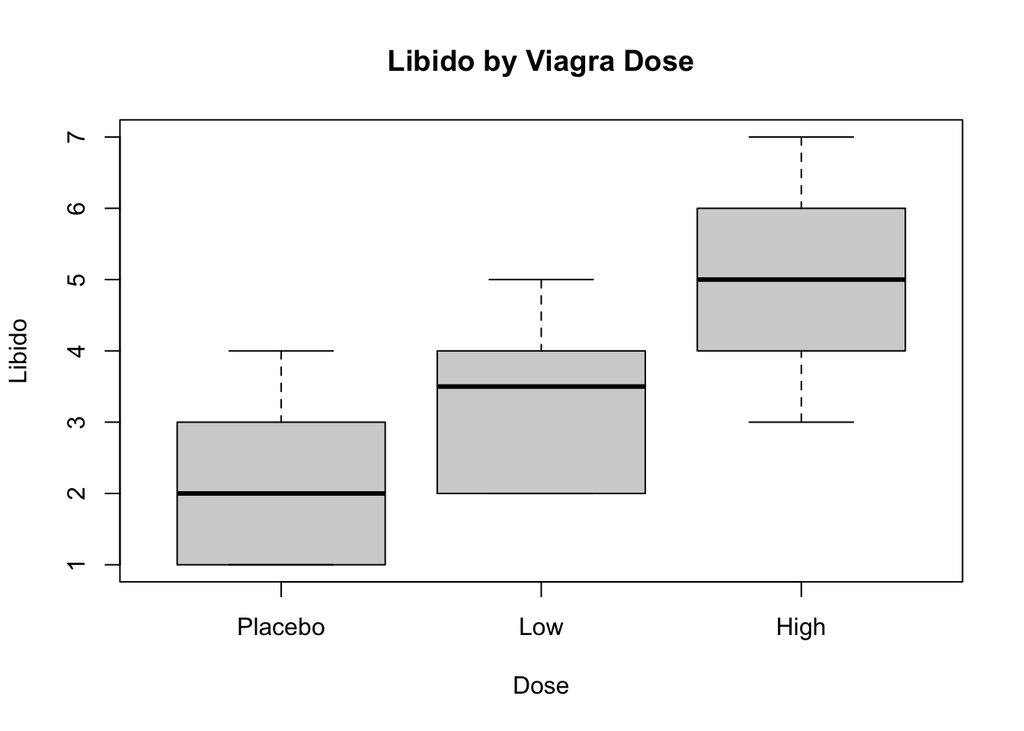

```r
boxplot(Libido ~ Dose, data = viagra, main = "Libido by Viagra Dose",
        xlab = "Dose", ylab = "Libido")
```

## 1.4 4. Assumptions (and the “residuals, not raw data” note)

- Normality check is typically applied to **residuals** (or model errors), not each raw group.
- Homogeneity of variance is commonly checked via Levene’s test.

### 1.4.1 4.1 Normality of residuals

```r
shapiro.test(residuals(m_oneway))
```

```
##
##  Shapiro-Wilk normality test
##
## data:  residuals(m_oneway)
## W = 0.92651, p-value = 0.0397
```

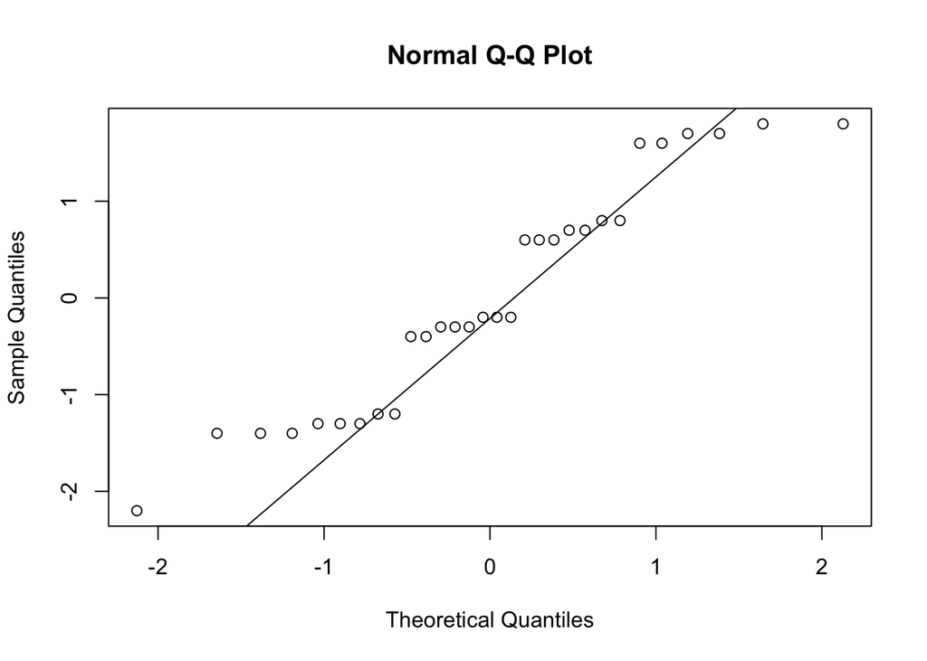

```r
qqnorm(residuals(m_oneway)); qqline(residuals(m_oneway))
```

### 1.4.2 4.2 Homogeneity of variance (Levene)

```r
# If not installed, run: install.packages("car")
library(car)
leveneTest(Libido ~ Dose, data = viagra)
```

```
## Levene's Test for Homogeneity of Variance (center = median)
##       Df F value Pr(>F)
## group  2  0.0672 0.9352
##       27
```

### 1.4.3 If homogeneity is violated: Welch ANOVA (optional)

```r
oneway.test(Libido ~ Dose, data = viagra, var.equal = FALSE)
```

```
##
##  One-way analysis of means (not assuming equal variances)
##
## data:  Libido and Dose
## F = 13.236, num df = 2.000, denom df = 17.946, p-value = 0.000294
```

## 1.5 5. Planned contrasts (orthogonal comparisons)

- Contrasts are **hypothesis-driven** comparisons.
- For 3 groups, we can test:
  1. Placebo vs (Low + High)
  2. Low vs High

### 1.5.1 Approach 1: Set custom contrasts in R

```r
viagra_c <- viagra
# Contrast 1: Placebo vs (Low+High)  -> (-2, +1, +1)
# Contrast 2: Low vs High           -> (0, -1, +1)
contrasts(viagra_c$Dose) <- cbind(
  Placebo_vs_Treated = c(-2, 1, 1),
  Low_vs_High        = c(0, -1, 1)
)

m_contrast <- aov(Libido ~ Dose, data = viagra_c)
summary(m_contrast)
```

```
##             Df Sum Sq Mean Sq F value   Pr(>F)
## Dose         2  42.87  21.433   14.43 5.46e-05 ***
## Residuals   27  40.10   1.485
## ---
## Signif. codes:  0 '***' 0.001 '**' 0.01 '*' 0.05 '.' 0.1 ' ' 1
```

### 1.5.2 Approach 2 (optional): Directly test specific comparisons using `emmeans`

If you want a more flexible workflow for follow-ups (still based on the `aov` fit).

```r
# install.packages("emmeans")
library(emmeans)

emm <- emmeans(m_oneway, ~ Dose)
emm
```

```
##  Dose    emmean    SE df lower.CL upper.CL
##  Placebo    2.3 0.385 27     1.51     3.09
##  Low        3.4 0.385 27     2.61     4.19
##  High       5.2 0.385 27     4.41     5.99
##
## Confidence level used: 0.95
```

```r
# Planned comparisons:
contrast(emm, list(
  Placebo_vs_Treated = c(-2, 1, 1),
  Low_vs_High        = c(0, -1, 1)
))
```

```
##  contrast           estimate    SE df t.ratio p.value
##  Placebo_vs_Treated      4.0 0.944 27   4.237  0.0002
##  Low_vs_High             1.8 0.545 27   3.303  0.0027
```

## 1.6 6. Post-hoc tests + multiple comparisons corrections

- Post-hoc tests are used when we did not specify planned contrasts beforehand.
- Pairwise t-tests with correction is the simplest teaching-friendly option.

```r
pairwise.t.test(viagra$Libido, viagra$Dose, p.adjust.method = "bonferroni")
```

```
##
##  Pairwise comparisons using t tests with pooled SD
##
## data:  viagra$Libido and viagra$Dose
##
##      Placebo Low
## Low  0.1608  -
## High 3.9e-05 0.0081
##
## P value adjustment method: bonferroni
```

```r
pairwise.t.test(viagra$Libido, viagra$Dose, p.adjust.method = "holm")
```

```
##
##  Pairwise comparisons using t tests with pooled SD
##
## data:  viagra$Libido and viagra$Dose
##
##      Placebo Low
## Low  0.0536  -
## High 3.9e-05 0.0054
##
## P value adjustment method: holm
```

### 1.6.1 Optional: Tukey HSD (classic ANOVA post-hoc for equal variances)

```r
TukeyHSD(m_oneway)
```

```
##   Tukey multiple comparisons of means
##     95% family-wise confidence level
##
## Fit: aov(formula = Libido ~ Dose, data = viagra)
##
## $Dose
##              diff      lwr     upr     p adj
## Low-Placebo   1.1 -0.25131 2.45131 0.1270744
## High-Placebo  2.9  1.54869 4.25131 0.0000374
## High-Low      1.8  0.44869 3.15131 0.0073729
```

## 1.7 7. One-way repeated-measures ANOVA (core)

### 1.7.1 Example B: Repeated measures across 3 conditions

Here we create a within-subject dataset in **long format**: - `Subject`: participant ID (factor) - `Condition`: within-subject factor - `Score`: DV

```r
set.seed(1)
rm_data <- expand.grid(
  Subject   = factor(1:18),
  Condition = factor(c("A", "B", "C"), levels = c("A", "B", "C"))
)

# Simulate a pattern: B > A, C highest
rm_data$Score <- with(rm_data,
  rnorm(nrow(rm_data),
        mean = ifelse(Condition == "A", 50,
               ifelse(Condition == "B", 55, 60)),
        sd = 6)
)

head(rm_data)
```

```
##   Subject Condition    Score
## 1       1         A 46.24128
## 2       2         A 51.10186
## 3       3         A 44.98623
## 4       4         A 59.57168
## 5       5         A 51.97705
## 6       6         A 45.07719
```

### 1.7.2 Repeated-measures ANOVA using `aov()` with `Error()`

```r
m_rm <- aov(Score ~ Condition + Error(Subject/Condition), data = rm_data)
summary(m_rm)
```

```
##
## Error: Subject
##           Df Sum Sq Mean Sq F value Pr(>F)
## Residuals 17  526.9      31
##
## Error: Subject:Condition
##           Df Sum Sq Mean Sq F value   Pr(>F)
## Condition  2  868.1   434.0   19.36 2.44e-06 ***
## Residuals 34  762.2    22.4
## ---
## Signif. codes:  0 '***' 0.001 '**' 0.01 '*' 0.05 '.' 0.1 ' ' 1
```

- This output is split into **Error strata**.
- Students should learn to locate the line for the within-subject effect (Condition).

## 1.8 8. When assumptions fail: Friedman’s ANOVA (non-parametric RM)

- Friedman is an alternative when repeated-measures assumptions are badly violated.
- Friedman requires wide-ish input (or you can reshape). We’ll reshape long→wide here.

```r
rm_wide <- reshape(rm_data, timevar = "Condition", idvar = "Subject", direction = "wide")
head(rm_wide)
```

```
##   Subject  Score.A  Score.B  Score.C
## 1       1 46.24128 59.92733 57.63426
## 2       2 51.10186 58.56341 59.64412
## 3       3 44.98623 60.51386 66.60015
## 4       4 59.57168 59.69282 64.57905
## 5       5 51.97705 55.44739 59.01286
## 6       6 45.07719 43.06389 58.47983
```

```r
friedman.test(as.matrix(rm_wide[, c("Score.A", "Score.B", "Score.C")]))
```

```
##
##  Friedman rank sum test
##
## data:  as.matrix(rm_wide[, c("Score.A", "Score.B", "Score.C")])
## Friedman chi-squared = 21, df = 2, p-value = 2.754e-05
```

### 1.8.1 Optional follow-up after Friedman

There are multiple approaches (Conover, pairwise Wilcoxon with correction).

```r
pairwise.wilcox.test(rm_data$Score, rm_data$Condition, paired = TRUE, p.adjust.method = "bonferroni")
```

```
##
##  Pairwise comparisons using Wilcoxon signed rank exact test
##
## data:  rm_data$Score and rm_data$Condition
##
##   A       B
## B 0.1295  -
## C 6.9e-05 0.0016
##
## P value adjustment method: bonferroni
```